## About

#### What is Time Series Econometrics on the go?

A web app for easy and on the go univariate time series econometrics. No installation required, just upload your data and start forecasting after a few clicks! The models available are:

- Exponential Smoothing (ETS) model
- Autoregressive iterated moving average (ARIMA) model
- General AutoRegressive Conditional Heteroskedasticity (GARCH) Model [TO COME]

#### Source Code

You can find all of the code for the app in [this GitHub repository](https://github.com/LlucPuigCodina/TSEonthego).

#### Learning

For those interested in learning more about the underlying models used in this app I recommend you take a look at some of the following resources:

- [Introductory Time Series with R](http://www.maths.adelaide.edu.au/andrew.metcalfe/) by Paul S.P. Cowpertwait and Andrew V. Metcalfe
- Time Series Analysis by James D. Hamilton

#### Author

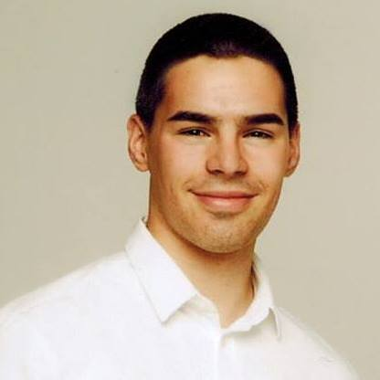

*Lluc Puig Codina*

MSc in Economics and Finance from the *Barcelona Graduate School of Economics* and Bachelor of Economics, with a minor in Advanced Quantitative Methods, from *Pompeu Fabra University*. Interested in many aspects of macroeconomic theory, finance and applied econometrics.

- Personal webpage: [llucpuigcodina.github.io](https://llucpuigcodina.github.io/)
- E-mail: llucpuigcodina[at]gmail.com

#### Acknowledgements

I would like to thank many people for their direct and indirect contribution to this project. First of all I would like to thank [Christian Brownless](http://84.89.132.1/~cbrownlees/), who thaught me forecasting (time series econometrics). I would also like to thank all those who contributed to the creation and development of the *R* language, *Rstudio*, *Shiny* and many of the packages used. Finally, I thank the [John Hopkins University Data Science Lab](http://jhudatascience.org/) for their didactic efforts and their [papr](https://jhubiostatistics.shinyapps.io/papr/) app, from which I shamelessly took the template.

#### Terms & Disclaimer

This app is for entertainment and didactic purposes only. No forecasts made with this app should be taken with any kind of value nor as advice.